# college_eda

Isaac

2022-03-14

## Abstract

As a project for my gap-year volunteer program. I started to work on some exploratory data analysis for the non-profit I help out with. As they have a focus on college mentorship across the U.S, this project had an emphasis on exploring what are the key characteristics of the colleges where we currently mentor at, with the hopes that by understanding what these key indicators are through data, it could aid in the discovery of new colleges where the non-profit can start new chapters of college mentorship programs for students. The data being used is sourced from the U.S government college scorecard database. A comprehensive and recent dataset that gathers demographic, admission, academic, and financial info of all colleges across the U.S. It is updated yearly and I am using their most recently dataset.

## techniques used

In this project, to quickly discern the differences between relevant variables, I decided to summarize findings through using correspondence analysis (CA) and linear regression comparing variables to take a closer look at individual relationships. One thing to note is that a lot of the variables I worked with are categorical in nature, so correspondence analysis is the right tool to be able to do data analysis, as I’ll explain in my findings

### Data Cleaning

```r
region_ccbasic <- table(dat$CCBASIC, dat$REGION)
region_ccbasic
```

```
##
##                                                                                            Far West
##   Associate's Colleges: High Career & Technical-High Nontraditional                               5
##   Associate's Colleges: High Career & Technical-High Traditional                                 14
##   Associate's Colleges: High Career & Technical-Mixed Traditional/Nontraditional                  6
##   Associate's Colleges: High Transfer-High Nontraditional                                         6
##   Associate's Colleges: High Transfer-High Traditional                                           33
##   Associate's Colleges: High Transfer-Mixed Traditional/Nontraditional                           34
##   Associate's Colleges: Mixed Transfer/Career & Technical-High Nontraditional                     6
##   Associate's Colleges: Mixed Transfer/Career & Technical-High Traditional                       21
##   Associate's Colleges: Mixed Transfer/Career & Technical-Mixed Traditional/Nontraditional       14
##   Baccalaureate Colleges: Arts & Sciences Focus                                                  21
##   Baccalaureate Colleges: Diverse Fields                                                         20
##   Baccalaureate/Associate's Colleges: Associate's Dominant                                       45
##   Baccalaureate/Associate's Colleges: Mixed Baccalaureate/Associate's                            11
##   Doctoral Universities: High Research Activity                                                   9
##   Doctoral Universities: Very High Research Activity                                             18
##   Doctoral/Professional Universities                                                             21
##   Master's Colleges & Universities: Larger Programs                                              46
##   Master's Colleges & Universities: Medium Programs                                              23
##   Master's Colleges & Universities: Small Programs                                               11
##   Not applicable                                                                                313
##   Special Focus Four-Year: Arts, Music & Design Schools                                          30
##   Special Focus Four-Year: Business & Management Schools                                         11
##   Special Focus Four-Year: Engineering Schools                                                    1
##   Special Focus Four-Year: Faith-Related Institutions                                            31
##   Special Focus Four-Year: Law Schools                                                            9
##   Special Focus Four-Year: Medical Schools & Centers                                              7
##   Special Focus Four-Year: Other Health Professions Schools                                      50
##   Special Focus Four-Year: Other Special Focus Institutions                                       6
##   Special Focus Four-Year: Other Technology-Related Schools                                       0
##   Special Focus Two-Year: Arts & Design                                                           2
##   Special Focus Two-Year: Health Professions                                                     33
##   Special Focus Two-Year: Other Fields                                                            9
##   Special Focus Two-Year: Technical Professions                                                   5
##   Tribal Colleges                                                                                 2
##
##                                                                                            Great Lakes
##   Associate's Colleges: High Career & Technical-High Nontraditional                                 33
##   Associate's Colleges: High Career & Technical-High Traditional                                    11
```

[output cut: 305 more lines]

```
##   Not applicable                                                                                              0
##   Special Focus Four-Year: Arts, Music & Design Schools                                                       0
##   Special Focus Four-Year: Business & Management Schools                                                      0
##   Special Focus Four-Year: Engineering Schools                                                                0
##   Special Focus Four-Year: Faith-Related Institutions                                                         0
##   Special Focus Four-Year: Law Schools                                                                        0
##   Special Focus Four-Year: Medical Schools & Centers                                                          0
##   Special Focus Four-Year: Other Health Professions Schools                                                   0
##   Special Focus Four-Year: Other Special Focus Institutions                                                   0
##   Special Focus Four-Year: Other Technology-Related Schools                                                   0
##   Special Focus Two-Year: Arts & Design                                                                       0
##   Special Focus Two-Year: Health Professions                                                                  0
##   Special Focus Two-Year: Other Fields                                                                        0
##   Special Focus Two-Year: Technical Professions                                                               0
##   Tribal Colleges                                                                                             0
```

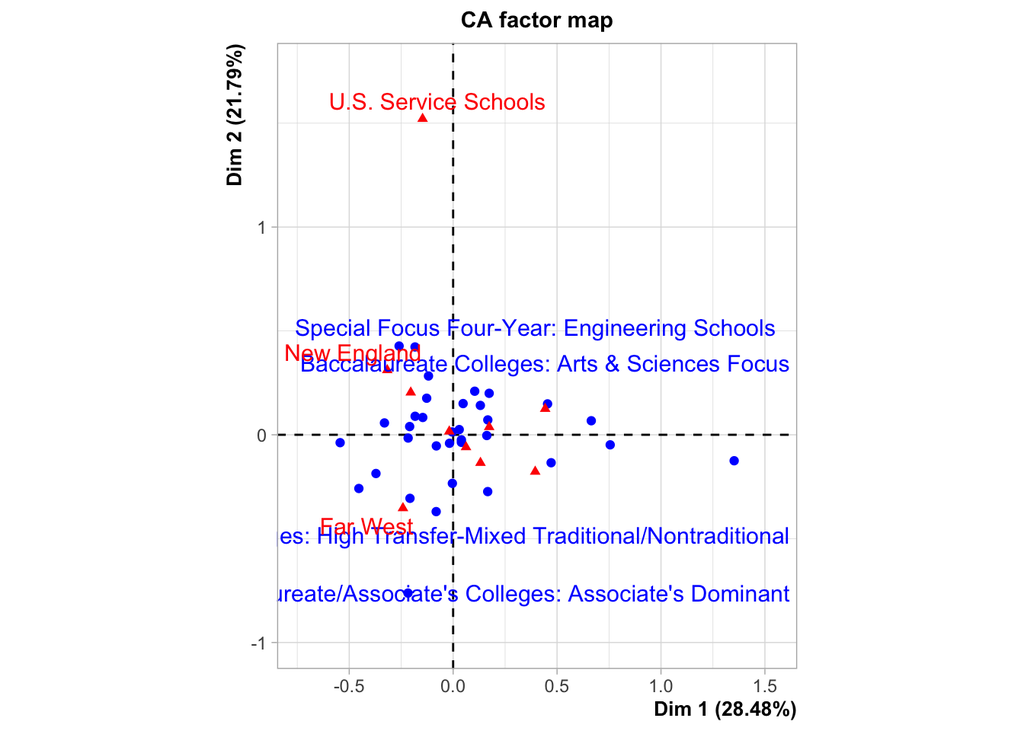

```
## **Results of the Correspondence Analysis (CA)**
## The row variable has  34  categories; the column variable has 10 categories
## The chi square of independence between the two variables is equal to 1056.33 (p-value =  1.1197e-85 ).
## *The results are available in the following objects:
##
##    name              description
## 1  "$eig"            "eigenvalues"
## 2  "$col"            "results for the columns"
## 3  "$col$coord"      "coord. for the columns"
## 4  "$col$cos2"       "cos2 for the columns"
## 5  "$col$contrib"    "contributions of the columns"
## 6  "$row"            "results for the rows"
## 7  "$row$coord"      "coord. for the rows"
## 8  "$row$cos2"       "cos2 for the rows"
## 9  "$row$contrib"    "contributions of the rows"
## 10 "$call"           "summary called parameters"
## 11 "$call$marge.col" "weights of the columns"
## 12 "$call$marge.row" "weights of the rows"
```

```r
CA(region_ccbasic)
```

```r
farwest_4yr <- dat %>% filter(REGION == "Far West") %>% select(c(1:316))

farwest_ccbasic_stabbr <-table(farwest_4yr$CCUGPROF, farwest_4yr$STABBR)

farwest_ccbasic_stabbr
```

```
##
##                                                                AK  CA  HI  NV
##   Four-year, full-time, inclusive, higher transfer-in           0  52   2   4
##   Four-year, full-time, inclusive, lower transfer-in            1  11   0   0
##   Four-year, full-time, more selective, higher transfer-in      0  19   1   0
##   Four-year, full-time, more selective, lower transfer-in       0  20   0   0
##   Four-year, full-time, selective, higher transfer-in           0  30   2   1
##   Four-year, full-time, selective, lower transfer-in            0   4   0   0
##   Four-year, higher part-time                                   4  42   2   6
##   Four-year, medium full-time , selective, higher transfer-in   0   4   2   1
##   Four-year, medium full-time, inclusive, higher transfer-in    1   9   0   0
##   Four-year, medium full-time, inclusive, lower transfer-in     0   2   0   0
##   Four-year, medium full-time, selective, lower transfer-in     0   1   0   0
##   N/A                                                           1 241   4  17
##   Not classified (Exclusively Graduate)                         0  56   1   1
##   Two-year, higher full-time                                    2  28   1   3
##   Two-year, higher part-time                                    0  93   4   1
##   Two-year, medium full-time                                    0   6   0   3
##   Two-year, mixed part/full-time                                0  11   2   0
##
##                                                                OR  WA
##   Four-year, full-time, inclusive, higher transfer-in           7  10
##   Four-year, full-time, inclusive, lower transfer-in            1   2
##   Four-year, full-time, more selective, higher transfer-in      2   3
##   Four-year, full-time, more selective, lower transfer-in       3   4
##   Four-year, full-time, selective, higher transfer-in           5   8
##   Four-year, full-time, selective, lower transfer-in            1   0
##   Four-year, higher part-time                                   4  11
##   Four-year, medium full-time , selective, higher transfer-in   3   0
##   Four-year, medium full-time, inclusive, higher transfer-in    4  17
##   Four-year, medium full-time, inclusive, lower transfer-in     0   3
##   Four-year, medium full-time, selective, lower transfer-in     0   0
##   N/A                                                          25  25
##   Not classified (Exclusively Graduate)                         3   3
##   Two-year, higher full-time                                    2   5
##   Two-year, higher part-time                                    4   0
##   Two-year, medium full-time                                    1   1
##   Two-year, mixed part/full-time                               13   7
```

```r
CA_farwest_ccbasic_stabbr <- CA(farwest_ccbasic_stabbr)
```

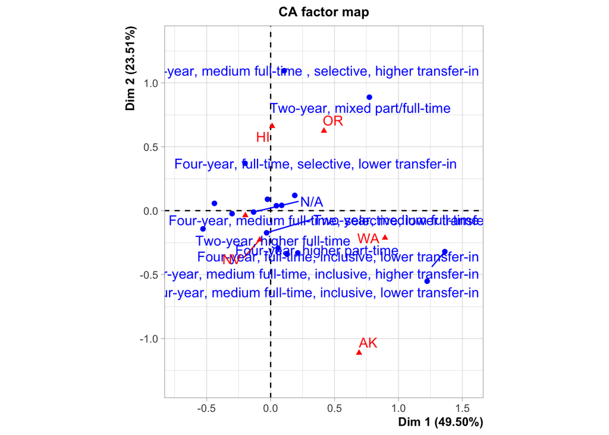

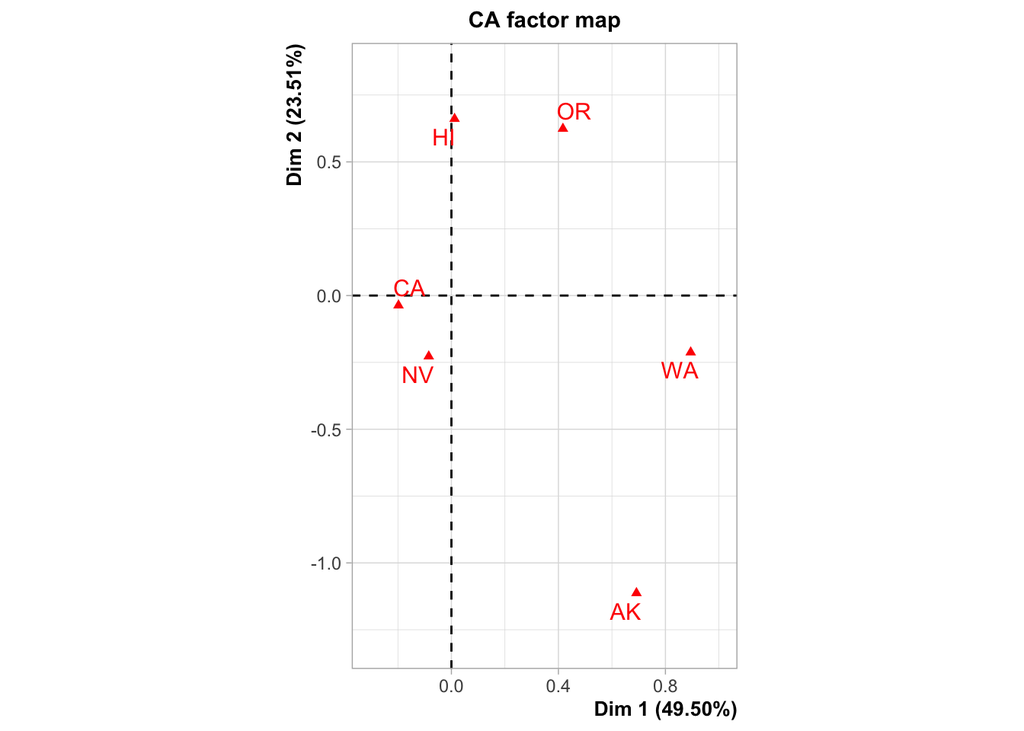

```r
plot(CA_farwest_ccbasic_stabbr, invisible = 'row')
```

```r
NE <- dat %>% filter(grepl("selective",CCUGPROF)) %>% filter(REGION == "New England") %>% select(c(1:316))

NE_ccbasic_stabbr <- table(NE$CCBASIC, NE$STABBR)

CA_NE_ccbasic_stabbr <- CA(NE_ccbasic_stabbr)
```

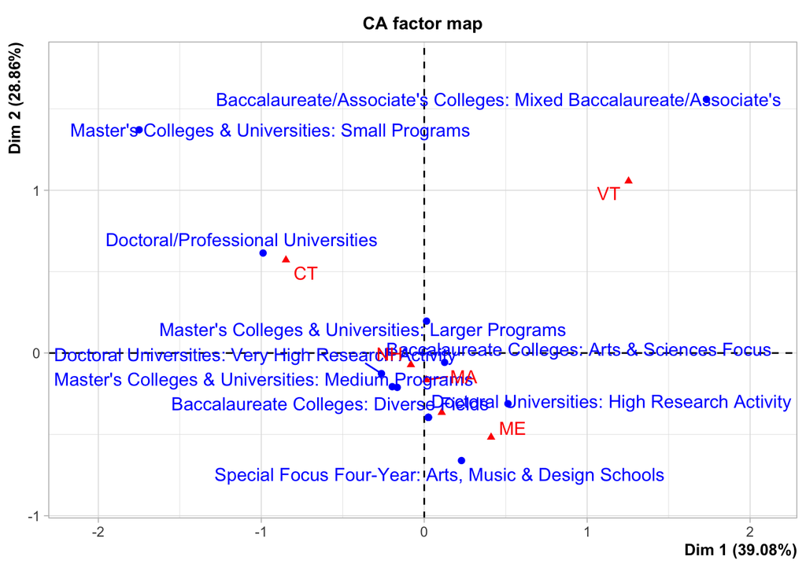

```r
CA_NE_ccbasic_stabbr$eig
```

```
##       eigenvalue percentage of variance cumulative percentage of variance
## dim 1 0.23522614              39.084674                          39.08467
## dim 2 0.17368270              28.858746                          67.94342
## dim 3 0.10306178              17.124525                          85.06795
## dim 4 0.05097148               8.469312                          93.53726
## dim 5 0.03889520               6.462743                         100.00000
```

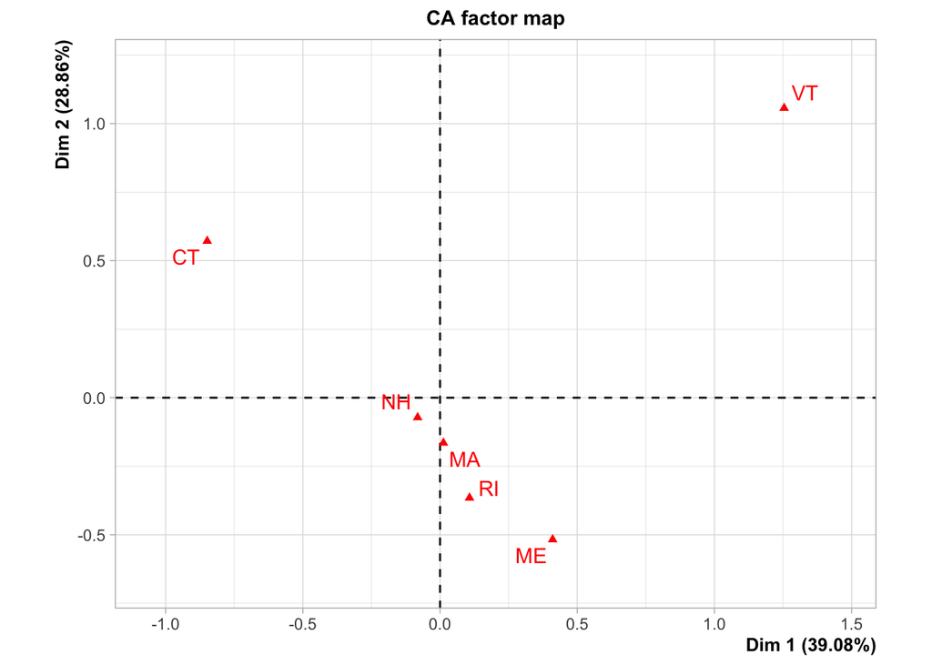

```r
plot(CA_NE_ccbasic_stabbr, invisible="row")
```

```r
# data cleaning: checking if filter is complete
gp_filter <- dat %>% filter(INSTNM %in% gp) %>% select(INSTNM)

gp <- data.frame(gp)
gp <- rename(gp, INSTNM = gp)

#gp %>% filter(!grepl(paste(gp_filter), INSTNM))

#filter(gp, !grepl(paste(gp_filter$INSTNM, collapse = "|"), INSTNM))
```

```r
gp_data<- dat %>% filter(INSTNM %in% gp$INSTNM) %>% select(1:316)
```

```r
gp_ccbasic_region <- table(gp_data$CCBASIC, gp_data$REGION)

CA_gp_ccbasic_region <- CA(gp_ccbasic_region)
```

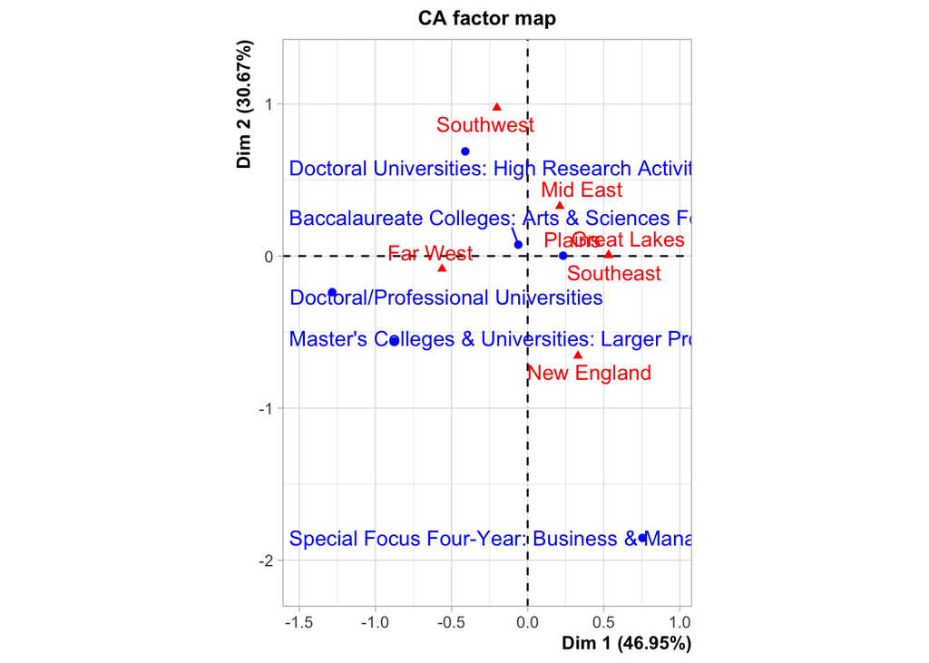

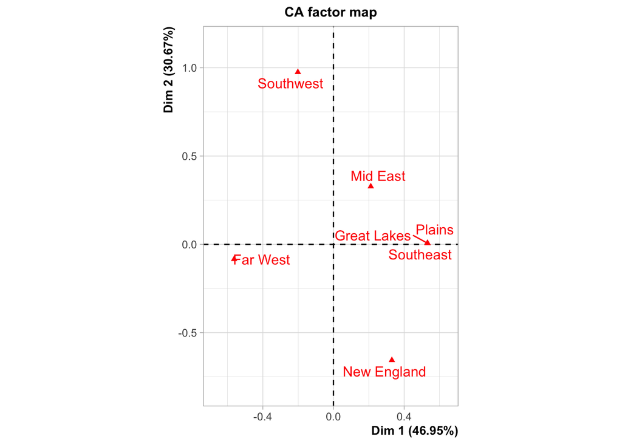

```r
plot(CA_gp_ccbasic_region, invisible="row")
```

```r
#install.packages("tidyverse")
#install.packages("sf")
#install.packages("mapview")

library(tidyverse)
library(sf)
library(mapview)
```

```r
gp_data$LATITUDE <- as.double(gp_data$LATITUDE)
gp_data$LONGITUDE <- as.double(gp_data$LONGITUDE)

mapview(gp_data, xcol = "LONGITUDE", ycol = "LATITUDE", crs = 4269, grid = FALSE)
```

[interactive chart not shown]

### statistics on gp_colleges